# **The History of Bitcoin**

[figure not shown]

# What is Bitcoin?

Decentralized cryptocurrency Bitcoin (BTC) was developed in 2009 by an unidentified person or group going by the name Satoshi Nakamoto. With no ties to established financial institutions, its goal is to facilitate peer-to-peer trades without the need of middlemen like banks or governments. Miners on the blockchain network validate bitcoin transactions in exchange for fresh bitcoins. Since its launch, Bitcoin has grown to be the most well-known and significant cryptocurrency, inspiring the creation of a large number of other virtual currencies.

[Investopedia](https://www.investopedia.com/terms/b/bitcoin.asp)

We have decided to dig deep into data of Bitcoin and analyze the trendline from when it began to recent date.

```python
import pandas as pd
import numpy as np
import datetime as dt
import matplotlib.pyplot as plt
```

```python
df = pd.read_csv("btc.csv")
df
```

|  | Date | Open | High | Low | Close | Volume |
| --- | --- | --- | --- | --- | --- | --- |
| 0 | 2010-07-18 | 0.0 | 0.1 | 0.1 | 0.1 | 8.000000e+01 |
| 1 | 2010-07-19 | 0.1 | 0.1 | 0.1 | 0.1 | 5.700000e+02 |
| 2 | 2010-07-20 | 0.1 | 0.1 | 0.1 | 0.1 | 2.600000e+02 |
| 3 | 2010-07-21 | 0.1 | 0.1 | 0.1 | 0.1 | 5.800000e+02 |
| 4 | 2010-07-22 | 0.1 | 0.1 | 0.1 | 0.1 | 2.160000e+03 |
| ... | ... | ... | ... | ... | ... | ... |
| 4989 | 2024-03-15 | 71387.9 | 72357.1 | 65630.7 | 69403.8 | 7.832045e+10 |
| 4990 | 2024-03-16 | 69392.5 | 70046.3 | 64801.4 | 65315.1 | 4.684220e+10 |
| 4991 | 2024-03-17 | 65316.3 | 68845.7 | 64545.3 | 68390.6 | 4.471686e+10 |
| 4992 | 2024-03-18 | 68371.3 | 68897.1 | 66594.2 | 67548.6 | 4.926158e+10 |
| 4993 | 2024-03-19 | 67556.1 | 68106.9 | 61536.2 | 61912.8 | 7.421584e+10 |

4994 rows × 6 columns

# At what price was bitcoin at when it first started?

```python
df.head(1) #least recent
```

|  | Date | Open | High | Low | Close | Volume |
| --- | --- | --- | --- | --- | --- | --- |
| 0 | 2010-07-18 | 0.0 | 0.1 | 0.1 | 0.1 | 80.0 |

On July 18, 2010, Bitcoin began trading at a value of 0.0. During the day, Bitcoin reached its peak at 0.1 before closing the day at the same value at 0.1

# What is the latest documented Bitcoin price?

```python
df.tail(1) #most recent
```

|  | Date | Open | High | Low | Close | Volume |
| --- | --- | --- | --- | --- | --- | --- |
| 4993 | 2024-03-19 | 67556.1 | 68106.9 | 61536.2 | 61912.8 | 7.421584e+10 |

On March 19, 2024, Bitcoin began trading at a price of 67,556.1. Throughout the day, its value fluctuated, reaching a peak of 68,106.9 and dropping to a low of 61,536.2. Eventually, it closed at 61,912.8.

# At what date did Bitcoin reach its' peak in price?

```python
max_price = df['High'].max()

df[df['High']==max_price] #the row that had the corresponding max
```

|  | Date | Open | High | Low | Close | Volume |
| --- | --- | --- | --- | --- | --- | --- |
| 4988 | 2024-03-14 | 73079.4 | 73750.1 | 68563.0 | 71396.6 | 5.959461e+10 |

On March 14, 2024, Bitcoin experienced its highest value of 73,750.1. It began the day at 73,079.4 and closed at 71,396.6. The lowest value it reached during the day was 68,563.0.

# Show a diagram illustrating the trendline of Bitcoin from the day it started to its most recent documented price

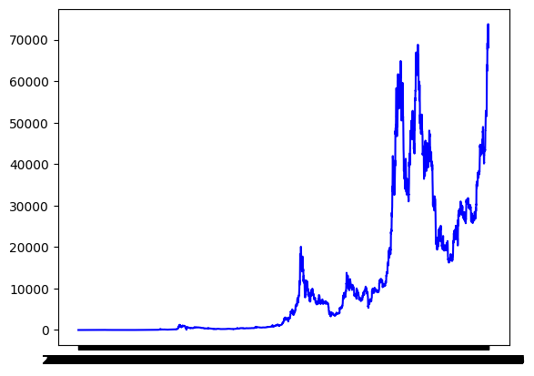

```python
plt.plot(df['Date'], df['High'], color='blue', label='Bitcoin Price')
```

# The World Health Organization labeled COVID-19 a global pandemic on March 13, 2020, which is noteworthy since it resulted in broad effects including lockdowns and global economic disruptions.

- What was the price on March 13th, 2020?
- What was the trendline following the lockdown? How much changed?
- What was it prior to the national lockdown?

```python
df.loc[df['Date']=='2020-03-13']
```

|  | Date | Open | High | Low | Close | Volume |
| --- | --- | --- | --- | --- | --- | --- |
| 3526 | 2020-03-13 | 5017.8 | 5838.1 | 4107.0 | 5563.7 | 7.415677e+10 |

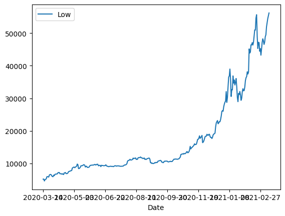

```python
dataframe = df.loc[df['Date']>'2020-03-13'].head(365) #the trendline following March 13th, 2020
dataframe.plot('Date','Low')
```

The graph suggests that Bitcoin's value started to rise consistently since March 13th, 2020. A year later, its lowest point was 14 (if round up to nearest integer) times higher than its initial value as provided below.

```python
year_later_low = df.loc[df['Date']=='2021-03-13', 'Low'].iloc[0]
year_later_low
```

```
56218.0
```

```python
beginning_low = df.loc[df['Date']=='2020-03-13', 'Low'].iloc[0]
beginning_low
```

```
4107.0
```

```python
multiplier_low = year_later_low/beginning_low
multiplier_low
```

```
13.688336985634283
```

We're checking how much the high value changed from March 13, 2020, to March 13, 2021. This tells us how many times the high value increased or decreased over the year

```python
year_later_high = df.loc[df['Date']=='2021-03-13', 'High'].iloc[0]
year_later_high
```

```
61683.9
```

```python
beginning_high = df.loc[df['Date']=='2020-03-13', 'High'].iloc[0]
beginning_high
```

```
5838.1
```

```python
multiplier_high = year_later_high/beginning_high
multiplier_high
```

```
10.565749130710334
```

The high value on March 13th, 2021, was about 11 times higher than the high value on March 13th, 2020.

# When did COVID-19 begin to cause concerns in the United States?

From samples collected on January 18 in Washington state, the CDC reports the first laboratory-confirmed case of the 2019 Novel Coronavirus in the United States. The same day, the CDC activates its Emergency Operations Center (EOC) to address the growing a pandemic

[cdc.gov](https://https://www.cdc.gov/museum/timeline/covid19.html)

```python
COVIDBTC = df.loc[(df['Date']<'2020-03-13') & (df['Date']>'2020-01-18')] #between January 18, 2020 and March 13, 2020
COVIDBTC
```

|  | Date | Open | High | Low | Close | Volume |
| --- | --- | --- | --- | --- | --- | --- |
| 3472 | 2020-01-19 | 8941.4 | 9164.4 | 8620.1 | 8706.2 | 3.421732e+10 |
| 3473 | 2020-01-20 | 8704.6 | 8745.6 | 8560.5 | 8657.6 | 2.642238e+10 |
| 3474 | 2020-01-21 | 8659.0 | 8755.7 | 8544.5 | 8745.9 | 2.409742e+10 |
| 3475 | 2020-01-22 | 8744.2 | 8793.0 | 8636.7 | 8680.9 | 2.260020e+10 |
| 3476 | 2020-01-23 | 8680.7 | 8687.7 | 8333.6 | 8406.5 | 2.577068e+10 |
| 3477 | 2020-01-24 | 8405.6 | 8514.7 | 8266.8 | 8445.4 | 2.439791e+10 |
| 3478 | 2020-01-25 | 8440.1 | 8458.5 | 8296.2 | 8367.8 | 1.964733e+10 |
| 3479 | 2020-01-26 | 8364.4 | 8602.4 | 8325.5 | 8596.8 | 2.217768e+10 |
| 3480 | 2020-01-27 | 8597.3 | 8977.7 | 8597.3 | 8909.8 | 2.864734e+10 |
| 3481 | 2020-01-28 | 8912.5 | 9358.6 | 8908.4 | 9358.6 | 3.439874e+10 |
| 3482 | 2020-01-29 | 9357.5 | 9406.4 | 9269.5 | 9316.6 | 3.068260e+10 |
| 3483 | 2020-01-30 | 9316.0 | 9553.1 | 9230.9 | 9509.0 | 3.237879e+10 |
| 3484 | 2020-01-31 | 9508.3 | 9521.7 | 9230.8 | 9350.5 | 2.943249e+10 |
| 3485 | 2020-02-01 | 9346.4 | 9439.3 | 9313.2 | 9392.9 | 2.592266e+10 |
| 3486 | 2020-02-02 | 9389.8 | 9468.8 | 9217.8 | 9344.4 | 3.083574e+10 |
| 3487 | 2020-02-03 | 9344.7 | 9540.4 | 9248.6 | 9293.5 | 3.093410e+10 |
| 3488 | 2020-02-04 | 9292.8 | 9331.3 | 9112.8 | 9181.0 | 2.989318e+10 |
| 3489 | 2020-02-05 | 9183.4 | 9701.3 | 9163.7 | 9613.4 | 3.522206e+10 |
| 3490 | 2020-02-06 | 9617.8 | 9824.6 | 9539.8 | 9729.8 | 3.762882e+10 |
| 3491 | 2020-02-07 | 9726.0 | 9834.7 | 9726.0 | 9795.9 | 3.452272e+10 |
| 3492 | 2020-02-08 | 9793.1 | 9876.7 | 9678.9 | 9865.1 | 3.517204e+10 |
| 3493 | 2020-02-09 | 9863.9 | 10129.4 | 9850.4 | 10116.7 | 3.580788e+10 |
| 3494 | 2020-02-10 | 10115.6 | 10165.8 | 9784.6 | 9856.6 | 3.938655e+10 |
| 3495 | 2020-02-11 | 9855.9 | 10210.1 | 9729.3 | 10208.2 | 3.764806e+10 |
| 3496 | 2020-02-12 | 10202.4 | 10393.6 | 10202.4 | 10326.1 | 4.344430e+10 |
| 3497 | 2020-02-13 | 10324.0 | 10457.6 | 10116.2 | 10214.4 | 4.935607e+10 |
| 3498 | 2020-02-14 | 10211.6 | 10322.0 | 10125.5 | 10312.1 | 4.333826e+10 |
| 3499 | 2020-02-15 | 10313.9 | 10341.6 | 9874.4 | 9889.4 | 4.386505e+10 |
| 3500 | 2020-02-16 | 9889.2 | 10054.0 | 9722.4 | 9934.4 | 4.337478e+10 |
| 3501 | 2020-02-17 | 9936.6 | 9938.8 | 9507.6 | 9690.1 | 4.599830e+10 |
| 3502 | 2020-02-18 | 9691.2 | 10161.9 | 9632.4 | 10142.0 | 4.727102e+10 |
| 3503 | 2020-02-19 | 10143.8 | 10191.7 | 9611.2 | 9633.4 | 4.699202e+10 |
| 3504 | 2020-02-20 | 9629.3 | 9643.2 | 9507.9 | 9608.5 | 4.492526e+10 |
| 3505 | 2020-02-21 | 9611.8 | 9723.0 | 9589.7 | 9686.4 | 4.093055e+10 |
| 3506 | 2020-02-22 | 9687.7 | 9698.2 | 9600.7 | 9663.2 | 3.583803e+10 |
| 3507 | 2020-02-23 | 9663.3 | 9937.4 | 9657.8 | 9924.5 | 4.118519e+10 |
| 3508 | 2020-02-24 | 9921.6 | 9951.7 | 9537.0 | 9650.2 | 4.508050e+10 |
| 3509 | 2020-02-25 | 9651.3 | 9652.7 | 9305.0 | 9341.7 | 4.251526e+10 |
| 3510 | 2020-02-26 | 9338.3 | 9354.8 | 8704.4 | 8820.5 | 5.042005e+10 |
| 3511 | 2020-02-27 | 8825.1 | 8932.9 | 8577.2 | 8784.5 | 4.547020e+10 |
| 3512 | 2020-02-28 | 8788.7 | 8890.5 | 8492.9 | 8672.5 | 4.460545e+10 |
| 3513 | 2020-02-29 | 8671.2 | 8775.6 | 8599.5 | 8599.5 | 3.579239e+10 |
| 3514 | 2020-03-01 | 8599.8 | 8726.8 | 8471.2 | 8562.5 | 3.534916e+10 |
| 3515 | 2020-03-02 | 8563.3 | 8921.3 | 8532.6 | 8869.7 | 4.285767e+10 |
| 3516 | 2020-03-03 | 8865.4 | 8901.6 | 8705.0 | 8787.8 | 4.238672e+10 |
| 3517 | 2020-03-04 | 8788.5 | 8843.4 | 8712.4 | 8755.2 | 3.474671e+10 |
| 3518 | 2020-03-05 | 8760.3 | 9142.1 | 8757.3 | 9078.8 | 3.969805e+10 |
| 3519 | 2020-03-06 | 9078.3 | 9167.7 | 9032.1 | 9122.5 | 4.082689e+10 |
| 3520 | 2020-03-07 | 9121.6 | 9163.2 | 8890.7 | 8910.0 | 3.621693e+10 |
| 3521 | 2020-03-08 | 8908.2 | 8914.3 | 8105.3 | 8108.1 | 3.997310e+10 |
| 3522 | 2020-03-09 | 8111.1 | 8177.8 | 7690.1 | 7923.6 | 4.693700e+10 |
| 3523 | 2020-03-10 | 7922.1 | 8136.9 | 7814.8 | 7909.7 | 4.221394e+10 |
| 3524 | 2020-03-11 | 7910.1 | 7950.8 | 7642.8 | 7911.4 | 3.868276e+10 |
| 3525 | 2020-03-12 | 7913.6 | 7929.1 | 4860.4 | 4970.8 | 5.398036e+10 |

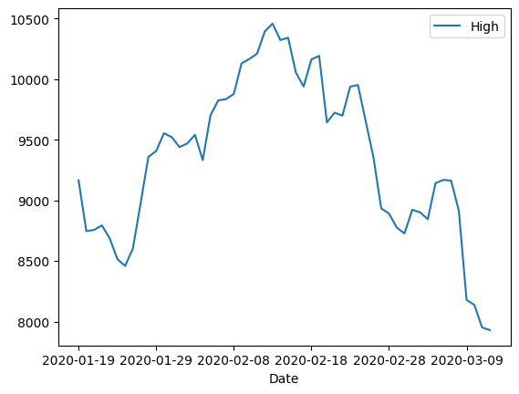

```python
COVIDBTC.plot(x='Date', y='High', kind='line')
```

The graph indicates that the values decreased noticeably as COVID-19 got worse and got closer to the day on which it was declared a epidemic in the United States on March 13.

# What is volume measuring?

Volume is a metric for trade activity and a good way to gauge market health. While decreasing prices with increasing volume point to a strengthening negative trend, rising markets with increasing volume are considered healthy. At fresh price highs or lows, decreasing volume might indicate a possible trend reversal.

[investopedia.com](https://www.investopedia.com/articles/technical/02/010702.asp)

It is important to see the trendlines in volume.

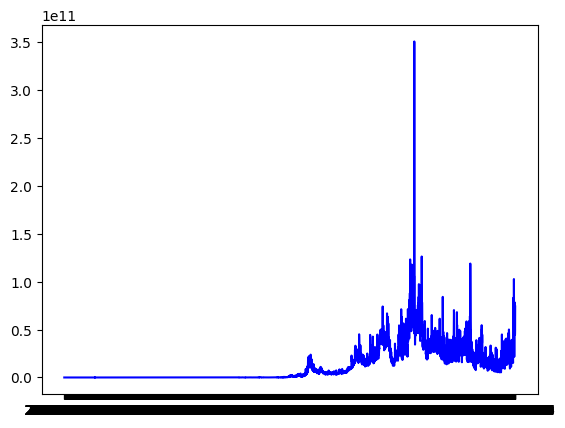

```python
plt.plot(df['Date'], df['Volume'], color='blue', label='Volume')
```

```python
max_volume_date = df[df['Volume'] == df['Volume'].max()]
max_volume_date['Date'].values[0]
```

```
'2021-02-26'
```

# There was a peak in the volume of Bitcoin exchanged on February 26, 2021.

- What does this indicate?

```python
df.loc[df['Date'] == '2021-02-26']
```

|  | Date | Open | High | Low | Close | Volume |
| --- | --- | --- | --- | --- | --- | --- |
| 3876 | 2021-02-26 | 47180.5 | 48370.8 | 44454.8 | 46339.8 | 3.509679e+11 |

The code above selects through all the data in the table and only selects the data we want. In this case it is the data for Feburary 26, 2021

```python
data_to_plot = df.loc[df['Date'] <= '2021-02-26'].tail(26)
data_to_plot #gets all the dates of Feburary
```

|  | Date | Open | High | Low | Close | Volume |
| --- | --- | --- | --- | --- | --- | --- |
| 3851 | 2021-02-01 | 33114.6 | 34638.2 | 32384.2 | 33537.2 | 6.140040e+10 |
| 3852 | 2021-02-02 | 33533.2 | 35896.9 | 33489.2 | 35510.3 | 6.308859e+10 |
| 3853 | 2021-02-03 | 35510.8 | 37480.2 | 35444.0 | 37472.1 | 6.116682e+10 |
| 3854 | 2021-02-04 | 37475.1 | 38592.2 | 36317.5 | 36926.1 | 6.883807e+10 |
| 3855 | 2021-02-05 | 36931.5 | 38225.9 | 36658.8 | 38144.3 | 5.859807e+10 |
| 3856 | 2021-02-06 | 38138.4 | 40846.5 | 38138.4 | 39266.0 | 7.132603e+10 |
| 3857 | 2021-02-07 | 39250.2 | 39621.8 | 37446.2 | 38903.4 | 6.550064e+10 |
| 3858 | 2021-02-08 | 38886.8 | 46203.9 | 38076.3 | 46196.5 | 1.014672e+11 |
| 3859 | 2021-02-09 | 46185.0 | 48003.7 | 45167.0 | 46481.1 | 9.180985e+10 |
| 3860 | 2021-02-10 | 46469.8 | 47145.6 | 43881.2 | 44918.2 | 8.730109e+10 |
| 3861 | 2021-02-11 | 44898.7 | 48463.5 | 44187.8 | 47909.3 | 8.138891e+10 |
| 3862 | 2021-02-12 | 47877.0 | 48745.7 | 46425.0 | 47504.9 | 7.655504e+10 |
| 3863 | 2021-02-13 | 47491.2 | 48047.7 | 46392.3 | 47105.5 | 7.025046e+10 |
| 3864 | 2021-02-14 | 47114.5 | 49487.6 | 47114.5 | 48717.3 | 7.124868e+10 |
| 3865 | 2021-02-15 | 48696.5 | 48875.6 | 46347.5 | 47945.1 | 7.706990e+10 |
| 3866 | 2021-02-16 | 47944.5 | 50341.1 | 47201.3 | 49199.9 | 7.704958e+10 |
| 3867 | 2021-02-17 | 49207.3 | 52533.9 | 49072.4 | 52149.0 | 8.082055e+10 |
| 3868 | 2021-02-18 | 52141.0 | 52474.1 | 51015.8 | 51679.8 | 5.205472e+10 |
| 3869 | 2021-02-19 | 51676.0 | 56113.7 | 50937.3 | 55888.1 | 6.349550e+10 |
| 3870 | 2021-02-20 | 55887.3 | 57505.2 | 54626.6 | 56099.5 | 6.814546e+10 |
| 3871 | 2021-02-21 | 56068.6 | 58330.6 | 55672.6 | 57539.9 | 5.189759e+10 |
| 3872 | 2021-02-22 | 57532.7 | 57533.4 | 48967.6 | 54207.3 | 9.205242e+10 |
| 3873 | 2021-02-23 | 54204.9 | 54204.9 | 45290.6 | 48824.4 | 1.061025e+11 |
| 3874 | 2021-02-24 | 48835.1 | 51290.1 | 47213.5 | 49705.3 | 6.369552e+10 |
| 3875 | 2021-02-25 | 49709.1 | 51949.0 | 47093.9 | 47093.9 | 5.450657e+10 |
| 3876 | 2021-02-26 | 47180.5 | 48370.8 | 44454.8 | 46339.8 | 3.509679e+11 |

The query above has selected the 25 days leading up to the peak in volume exchange. Queries like this can be used to analyze trends before an event occurs. We can see that the peak close was at about 57,000 but by the time peak volume was traded, the close was only about 46,000.

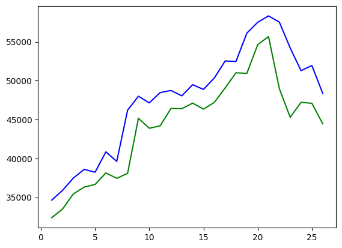

```python
data_to_plot['Date'] = pd.to_datetime(data_to_plot['Date'])
plt.plot(data_to_plot['Date'].dt.day, data_to_plot['High'], color='blue', label='High')
plt.plot(data_to_plot['Date'].dt.day, data_to_plot['Low'], color='green', label='Low')
```

The graph above is used to analyze both the highs and lows in price over a month. Often time day traders will use graphs like this to analyze trends such as supply and demand to make educated decision on when to buy and sell. In this case we could maybe conclude that holders got scared of the price fall after the peak leading to the highest volume of bitcoin being exchanged.

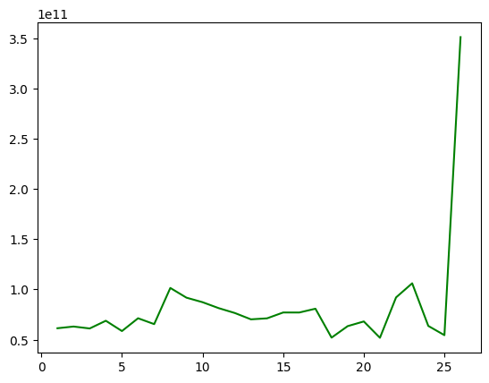

```python
plt.plot(data_to_plot['Date'].dt.day, data_to_plot['Volume'], color='green', label='High')
```

A decline in a financial asset's price accompanied by an increase in trading volume indicates that more individuals are selling the asset. Because traders anticipate that the price will continue to decline, this suggests a greater negative trend. Thus, additional price declines are expected to follow if prices continue to decline and trading volume remains high. Comparing the two graphs, the volume appears to be spiking while the high value around that time is decreasing.

[investopedia.com](https://www.investopedia.com/terms/v/volume-analysis.asp)

# Calculating various statisitcs

- Mean
- Standard Deviation

```python
btc = pd.read_csv('btc.csv')
```

```python
low_array = btc['Low'].values #an array of low values
print(f'The Low Price Average across 4 years is: ${np.average(low_array)}') #using numpy to calculate the low value average across the low value array
```

[output not shown]

```python
open_array = btc['Open'].values #an array of open values
print(f'The Opening Price Average across 4 years is: ${np.average(open_array)}') #using numpy to calculate the open value average across the open value array
```

[output not shown]

```python
high_array = btc['High'].values #an array of high values
print(f'The High Price Average across 4 years is: ${np.average(high_array)}') #using numpy to calculate the high value average across the high value array
```

[output not shown]

```python
close_array = btc['Close'].values #an array of close values
print(f'The Closing Price Average across 4 years is: ${np.average(close_array)}') #using numpy to calculate the close value average across the close value array
```

[output not shown]

The data mentioned above is used to illustrate the mean values for the terms "high," "open," "low," and "close" from July 2010 to March 2024.

# At what point were the values close to the average by 500?

```python
filtered_high_values = df[df['High'].map(lambda high_value: abs(high_value - np.average(high_array)) < 500)]
filtered_high_values #using a lambda function allows the calculation to occur, which maps out all of the values that meet the condition
```

|  | Date | Open | High | Low | Close | Volume |
| --- | --- | --- | --- | --- | --- | --- |
| 2692 | 2017-11-30 | 9906.8 | 10801.0 | 9202.0 | 10233.6 | 8.310690e+09 |
| 2693 | 2017-12-01 | 10198.6 | 11046.7 | 9694.7 | 10975.6 | 6.783120e+09 |
| 2694 | 2017-12-02 | 10978.3 | 11320.2 | 10905.1 | 11074.6 | 5.138500e+09 |
| 2746 | 2018-01-23 | 10944.5 | 11377.6 | 10129.7 | 10868.4 | 9.660610e+09 |
| 2747 | 2018-01-24 | 10903.4 | 11501.4 | 10639.8 | 11359.4 | 9.940990e+09 |
| ... | ... | ... | ... | ... | ... | ... |
| 3736 | 2020-10-09 | 10927.9 | 11102.7 | 10846.9 | 11064.5 | 2.279912e+10 |
| 3737 | 2020-10-10 | 11059.1 | 11442.2 | 11056.9 | 11296.4 | 2.287798e+10 |
| 3738 | 2020-10-11 | 11296.1 | 11428.8 | 11288.6 | 11384.2 | 1.996863e+10 |
| 3744 | 2020-10-17 | 11322.1 | 11386.3 | 11285.3 | 11358.1 | 1.913043e+10 |
| 3745 | 2020-10-18 | 11356.0 | 11483.4 | 11347.6 | 11483.4 | 1.828331e+10 |

90 rows × 6 columns

This code measures the absolute difference between each value in the "high" column and the average of the high array. This is a useful piece of code because it can help to remove outliers, clean data, and reduce noise.

```python
filtered_low_values = df[df['Low'].map(lambda low_value: abs(low_value - np.average(low_array)) < 500)]
filtered_low_values #using a lambda function allows the calculation to occur, which maps out all of the values that meet the condition
```

|  | Date | Open | High | Low | Close | Volume |
| --- | --- | --- | --- | --- | --- | --- |
| 2694 | 2017-12-02 | 10978.3 | 11320.2 | 10905.1 | 11074.6 | 5.138500e+09 |
| 2695 | 2017-12-03 | 11082.7 | 11858.7 | 10862.0 | 11323.2 | 6.608310e+09 |
| 2739 | 2018-01-16 | 13836.1 | 13843.1 | 10194.9 | 11490.5 | 1.885380e+10 |
| 2741 | 2018-01-18 | 11198.8 | 12107.3 | 10942.5 | 11474.9 | 1.502040e+10 |
| 2745 | 2018-01-22 | 11633.1 | 11966.4 | 10240.2 | 10931.4 | 1.053740e+10 |
| ... | ... | ... | ... | ... | ... | ... |
| 3732 | 2020-10-05 | 10676.5 | 10793.5 | 10634.6 | 10793.3 | 4.753758e+10 |
| 3733 | 2020-10-06 | 10796.3 | 10797.6 | 10528.9 | 10604.4 | 4.262370e+10 |
| 3734 | 2020-10-07 | 10603.4 | 10680.5 | 10562.5 | 10669.0 | 3.779946e+10 |
| 3735 | 2020-10-08 | 10669.4 | 10945.7 | 10562.6 | 10915.7 | 6.331479e+10 |
| 3736 | 2020-10-09 | 10927.9 | 11102.7 | 10846.9 | 11064.5 | 2.279912e+10 |

106 rows × 6 columns

This is essentially the same thing, but look at this lows. Once again, this can help normalize data and reduce noise to focus on only the relevant data.

```python
filtered_open_values = df[df['Open'].map(lambda open_value: abs(open_value - np.average(open_array)) < 500)]
filtered_open_values #using a lambda function allows the calculation to occur, which maps out all of the values that meet the condition
```

|  | Date | Open | High | Low | Close | Volume |
| --- | --- | --- | --- | --- | --- | --- |
| 2694 | 2017-12-02 | 10978.3 | 11320.2 | 10905.1 | 11074.6 | 5.138500e+09 |
| 2695 | 2017-12-03 | 11082.7 | 11858.7 | 10862.0 | 11323.2 | 6.608310e+09 |
| 2741 | 2018-01-18 | 11198.8 | 12107.3 | 10942.5 | 11474.9 | 1.502040e+10 |
| 2746 | 2018-01-23 | 10944.5 | 11377.6 | 10129.7 | 10868.4 | 9.660610e+09 |
| 2747 | 2018-01-24 | 10903.4 | 11501.4 | 10639.8 | 11359.4 | 9.940990e+09 |
| ... | ... | ... | ... | ... | ... | ... |
| 3733 | 2020-10-06 | 10796.3 | 10797.6 | 10528.9 | 10604.4 | 4.262370e+10 |
| 3734 | 2020-10-07 | 10603.4 | 10680.5 | 10562.5 | 10669.0 | 3.779946e+10 |
| 3735 | 2020-10-08 | 10669.4 | 10945.7 | 10562.6 | 10915.7 | 6.331479e+10 |
| 3736 | 2020-10-09 | 10927.9 | 11102.7 | 10846.9 | 11064.5 | 2.279912e+10 |
| 3737 | 2020-10-10 | 11059.1 | 11442.2 | 11056.9 | 11296.4 | 2.287798e+10 |

101 rows × 6 columns

```python
filtered_close_values = df[df['Close'].map(lambda close_value: abs(close_value - np.average(close_array)) < 500)]
filtered_close_values #using a lambda function allows the calculation to occur, which maps out all of the values that meet the condition
```

|  | Date | Open | High | Low | Close | Volume |
| --- | --- | --- | --- | --- | --- | --- |
| 2693 | 2017-12-01 | 10198.6 | 11046.7 | 9694.7 | 10975.6 | 6.783120e+09 |
| 2694 | 2017-12-02 | 10978.3 | 11320.2 | 10905.1 | 11074.6 | 5.138500e+09 |
| 2740 | 2018-01-17 | 11431.1 | 11678.0 | 9402.3 | 11188.6 | 1.883060e+10 |
| 2745 | 2018-01-22 | 11633.1 | 11966.4 | 10240.2 | 10931.4 | 1.053740e+10 |
| 2746 | 2018-01-23 | 10944.5 | 11377.6 | 10129.7 | 10868.4 | 9.660610e+09 |
| ... | ... | ... | ... | ... | ... | ... |
| 3732 | 2020-10-05 | 10676.5 | 10793.5 | 10634.6 | 10793.3 | 4.753758e+10 |
| 3733 | 2020-10-06 | 10796.3 | 10797.6 | 10528.9 | 10604.4 | 4.262370e+10 |
| 3734 | 2020-10-07 | 10603.4 | 10680.5 | 10562.5 | 10669.0 | 3.779946e+10 |
| 3735 | 2020-10-08 | 10669.4 | 10945.7 | 10562.6 | 10915.7 | 6.331479e+10 |
| 3736 | 2020-10-09 | 10927.9 | 11102.7 | 10846.9 | 11064.5 | 2.279912e+10 |

101 rows × 6 columns

The two tables and code above are doing the same thing as the high and low are doing but with the opening and closing price. This can help to see the trend of how the bitcoin market is moving.

# What is the Standard Deviation for all values (High, Low, Open, Close)?

```python
high_std = np.std(high_array) #using numpy to calculate standard deviation
high_std
```

```
16174.666115063894
```

```python
low_std = np.std(low_array) #using numpy to calculate standard deviation
low_std
```

```
15383.539299934531
```

```python
open_std = np.std(open_array) #using numpy to calculate standard deviation
open_std
```

```
15796.528033999386
```

```python
close_std = np.std(close_array) #using numpy to calculate standard deviation
close_std
```

```
15810.181663035726
```

# What can we conclude about this data?

From this data, we can conclude that the high values are more spread out because the standard deviation is the highest among all the other standard deviation values. We can also conclude that the low values are generally more clustered together. Although, all standard deviation values are significantly high, indicating that the data is spread out.